# STAT 420: Homework 10

Fall 2016, sirasao2 // Rahul Sirasao

Due: Wednesday, December 7 by 11:50 PM CT

# Assignment

## Exercise 1 (`prostate` Data)

Using the `prostate` dataset from the `faraway` package, fit a model with `lpsa` as the response and the other variables as predictors. For this exercise only consider first order predictors.

```r
library(leaps)
library(faraway)
data("prostate")
```

**(a)** Find the model with the **best** AIC. Report the predictors that are used in the resulting model.

```r
mod_1 <- lm(lpsa ~., data= prostate)
mod1_aic = step(mod_1, direction ="backward")
```

```
## Start:  AIC=-58.32
## lpsa ~ lcavol + lweight + age + lbph + svi + lcp + gleason +
##     pgg45
##
##           Df Sum of Sq  RSS   AIC
## - gleason  1      0.04 44.2 -60.2
## - pgg45    1      0.53 44.7 -59.2
## - lcp      1      0.67 44.8 -58.9
## <none>                 44.2 -58.3
## - age      1      1.55 45.7 -57.0
## - lbph     1      1.68 45.8 -56.7
## - lweight  1      3.59 47.7 -52.7
## - svi      1      4.94 49.1 -50.0
## - lcavol   1     22.37 66.5 -20.6
##
## Step:  AIC=-60.23
## lpsa ~ lcavol + lweight + age + lbph + svi + lcp + pgg45
##
##           Df Sum of Sq  RSS   AIC
## - lcp      1      0.66 44.9 -60.8
## <none>                 44.2 -60.2
## - pgg45    1      1.19 45.4 -59.7
## - age      1      1.52 45.7 -59.0
## - lbph     1      1.71 45.9 -58.6
## - lweight  1      3.55 47.8 -54.7
## - svi      1      4.90 49.1 -52.0
## - lcavol   1     23.50 67.7 -20.9
##
## Step:  AIC=-60.79
## lpsa ~ lcavol + lweight + age + lbph + svi + pgg45
##
##           Df Sum of Sq  RSS   AIC
## - pgg45    1      0.66 45.5 -61.4
## <none>                 44.9 -60.8
## - age      1      1.26 46.1 -60.1
## - lbph     1      1.65 46.5 -59.3
## - lweight  1      3.56 48.4 -55.4
## - svi      1      4.25 49.1 -54.0
## - lcavol   1     25.42 70.3 -19.2
##
## Step:  AIC=-61.37
## lpsa ~ lcavol + lweight + age + lbph + svi
##
##           Df Sum of Sq  RSS   AIC
## <none>                 45.5 -61.4
## - age      1      0.96 46.5 -61.4
## - lbph     1      1.86 47.4 -59.5
## - lweight  1      3.23 48.8 -56.7
## - svi      1      5.95 51.5 -51.5
## - lcavol   1     28.77 74.3 -15.9
```

```r
mod1_aic$call
```

```
## lm(formula = lpsa ~ lcavol + lweight + age + lbph + svi, data = prostate)
```

```r
#From what I am observing the best model would be m(formula = lpsa ~ lcavol + lweight + age + lbph + svi, data = prostate)
```

**(b)** Find the model with the **best** BIC. Report the predictors that are used in the resulting model.

```r
mod1_bic = step(mod_1,direction = "backward", k = log(length(resid(mod_1))))
```

```
## Start:  AIC=-35.15
## lpsa ~ lcavol + lweight + age + lbph + svi + lcp + gleason +
##     pgg45
##
##           Df Sum of Sq  RSS   AIC
## - gleason  1      0.04 44.2 -39.6
## - pgg45    1      0.53 44.7 -38.6
## - lcp      1      0.67 44.8 -38.3
## - age      1      1.55 45.7 -36.4
## - lbph     1      1.68 45.8 -36.1
## <none>                 44.2 -35.1
## - lweight  1      3.59 47.7 -32.2
## - svi      1      4.94 49.1 -29.4
## - lcavol   1     22.37 66.5   0.0
##
## Step:  AIC=-39.63
## lpsa ~ lcavol + lweight + age + lbph + svi + lcp + pgg45
##
##           Df Sum of Sq  RSS   AIC
## - lcp      1      0.66 44.9 -42.8
## - pgg45    1      1.19 45.4 -41.6
## - age      1      1.52 45.7 -40.9
## - lbph     1      1.71 45.9 -40.5
## <none>                 44.2 -39.6
## - lweight  1      3.55 47.8 -36.7
## - svi      1      4.90 49.1 -34.0
## - lcavol   1     23.50 67.7  -2.8
##
## Step:  AIC=-42.77
## lpsa ~ lcavol + lweight + age + lbph + svi + pgg45
##
##           Df Sum of Sq  RSS   AIC
## - pgg45    1      0.66 45.5 -45.9
## - age      1      1.26 46.1 -44.6
## - lbph     1      1.65 46.5 -43.8
## <none>                 44.9 -42.8
## - lweight  1      3.56 48.4 -39.9
## - svi      1      4.25 49.1 -38.6
## - lcavol   1     25.42 70.3  -3.8
##
```

[output cut: 14 more lines]

```
##           Df Sum of Sq  RSS   AIC
## - lbph     1      1.30 47.8 -50.4
## <none>                 46.5 -48.5
## - lweight  1      2.80 49.3 -47.4
## - svi      1      5.81 52.3 -41.6
## - lcavol   1     27.83 74.3  -7.5
##
## Step:  AIC=-50.38
## lpsa ~ lcavol + lweight + svi
##
##           Df Sum of Sq  RSS   AIC
## <none>                 47.8 -50.4
## - svi      1      5.18 53.0 -45.0
## - lweight  1      5.89 53.7 -43.7
## - lcavol   1     28.04 75.8 -10.2
```

```r
mod1_bic$call
```

```
## lm(formula = lpsa ~ lcavol + lweight + svi, data = prostate)
```

```r
#From what I see the preffered model is lm(formula = lpsa ~ lcavol + lweight + svi, data = prostate).
```

**(c)** Find the model with the **best** Adjusted $R^2$. Report the predictors that are used in the resulting model.

```r
all <- regsubsets(lpsa ~ ., data=prostate)
cbind(summary(all)$which[,-1], "Adj R-sq"=summary(all)$adjr2)
```

```
##   lcavol lweight age lbph svi lcp gleason pgg45 Adj R-sq
## 1      1       0   0    0   0   0       0     0   0.5346
## 2      1       1   0    0   0   0       0     0   0.5771
## 3      1       1   0    0   1   0       0     0   0.6144
## 4      1       1   0    1   1   0       0     0   0.6208
## 5      1       1   1    1   1   0       0     0   0.6245
## 6      1       1   1    1   1   0       0     1   0.6259
## 7      1       1   1    1   1   1       0     1   0.6273
## 8      1       1   1    1   1   1       1     1   0.6234
```

```r
#We see a model with 7 predictors. This has a best adjusted r-squared. It's predictors are as we see lcavol, lweight, age, lbph, svi, lcp, and pgg45.
```

```r
pred_mod <- lm(lpsa ~ lcavol + lweight + age + lbph + svi + lcp + pgg45, data = prostate)
```

**(d)** Of the four models you just considered, some of which *may* be the same, which is the best for making predictions? Use leave-one-out-cross-validated MSE or RMSE to decide.

```r
rmse = function(model) {
  sqrt(mean((resid(model) / (1 - hatvalues(model))) ^ 2))
}
```

```r
rmse(mod_1)
```

```
## [1] 0.7477
```

```r
rmse(mod1_aic)
```

```
## [1] 0.7369
```

```r
rmse(mod1_bic)
```

```
## [1] 0.7381
```

```r
rmse(pred_mod)
```

```
## [1] 0.7411
```

```r
#We see the aic model with smallest rmse of 0.736896 will be the best for making pedictors.
```

## Exercise 2 (Goalies Data, revisited)

**(a)** Use the data found in `goalies_cleaned.csv` to find a “good” model for wins, `W`. Use any methods seen in class. The model should reach a `Multiple R-squared` above `0.99` using fewer than 37 parameters. Hint: you may want to look into the ability to add many interactions quickly in `R`.

```r
gc <- read.csv("~/Downloads/goalies_cleaned(1).csv", comment.char="#")
full_gc <- lm(W ~., data= gc)
gc_aic = step(full_gc, direction ="backward")
```

```
## Start:  AIC=2344
## W ~ GA + SA + SV + SV_PCT + GAA + SO + MIN + PIM
##
##          Df Sum of Sq    RSS  AIC
## - GAA     1         2  70995 2342
## - SV_PCT  1        33  71026 2342
## <none>                 70994 2344
## - SO      1       838  71831 2347
## - PIM     1      1849  72843 2354
## - SA      1      2274  73267 2357
## - SV      1      2332  73326 2357
## - GA      1      9171  80164 2398
## - MIN     1     30138 101131 2506
##
## Step:  AIC=2342
## W ~ GA + SA + SV + SV_PCT + SO + MIN + PIM
##
##          Df Sum of Sq    RSS  AIC
## - SV_PCT  1        46  71041 2340
## <none>                 70995 2342
## - SO      1       836  71831 2345
## - PIM     1      1848  72843 2352
## - SA      1      2280  73275 2355
## - SV      1      2339  73334 2355
## - GA      1      9226  80221 2397
## - MIN     1     30320 101315 2504
##
## Step:  AIC=2340
## W ~ GA + SA + SV + SO + MIN + PIM
##
##        Df Sum of Sq    RSS  AIC
## <none>               71041 2340
## - SO    1       861  71903 2344
## - PIM   1      1857  72899 2350
## - SA    1      2322  73363 2353
## - SV    1      2383  73425 2354
## - GA    1      9183  80224 2395
## - MIN   1     30276 101317 2502
```

```r
gc_aic$call
```

```
## lm(formula = W ~ GA + SA + SV + SO + MIN + PIM, data = gc)
```

```r
#BIC

gc_bic = step(full_gc,direction = "backward", k = log(length(resid(full_gc))))
```

```
## Start:  AIC=2381
## W ~ GA + SA + SV + SV_PCT + GAA + SO + MIN + PIM
##
##          Df Sum of Sq    RSS  AIC
## - GAA     1         2  70995 2375
## - SV_PCT  1        33  71026 2375
## - SO      1       838  71831 2381
## <none>                 70994 2381
## - PIM     1      1849  72843 2387
## - SA      1      2274  73267 2390
## - SV      1      2332  73326 2390
## - GA      1      9171  80164 2431
## - MIN     1     30138 101131 2539
##
## Step:  AIC=2375
## W ~ GA + SA + SV + SV_PCT + SO + MIN + PIM
##
##          Df Sum of Sq    RSS  AIC
## - SV_PCT  1        46  71041 2369
## - SO      1       836  71831 2374
## <none>                 70995 2375
## - PIM     1      1848  72843 2381
## - SA      1      2280  73275 2384
## - SV      1      2339  73334 2384
## - GA      1      9226  80221 2425
## - MIN     1     30320 101315 2533
##
## Step:  AIC=2369
## W ~ GA + SA + SV + SO + MIN + PIM
##
##        Df Sum of Sq    RSS  AIC
## - SO    1       861  71903 2369
## <none>               71041 2369
## - PIM   1      1857  72899 2375
## - SA    1      2322  73363 2378
## - SV    1      2383  73425 2378
## - GA    1      9183  80224 2419
## - MIN   1     30276 101317 2527
##
## Step:  AIC=2369
## W ~ GA + SA + SV + MIN + PIM
##
##        Df Sum of Sq    RSS  AIC
## <none>               71903 2369
## - PIM   1      1564  73466 2373
## - SA    1      2248  74151 2377
## - SV    1      2338  74241 2377
## - GA    1     23929  95831 2495
## - MIN   1     95477 167380 2753
```

```r
gc_bic$call
```

```
## lm(formula = W ~ GA + SA + SV + MIN + PIM, data = gc)
```

```r
#Decided Model
opt_model= lm(W~  MIN + PIM +SO * GA * SA * SV * SV_PCT, data=gc)
summary(opt_model)
```

```
##
## Call:
## lm(formula = W ~ MIN + PIM + SO * GA * SA * SV * SV_PCT, data = gc)
##
## Residuals:
##    Min     1Q Median     3Q    Max
## -41.63  -2.48   0.00   2.38  57.70
##
## Coefficients:
##                     Estimate Std. Error t value Pr(>|t|)
## (Intercept)        -8.34e+00   9.49e+00   -0.88  0.37983
## MIN                 1.60e-02   9.33e-04   17.15  < 2e-16 ***
## PIM                 3.80e-02   1.37e-02    2.78  0.00571 **
## SO                  3.54e+01   1.78e+01    1.99  0.04764 *
## GA                 -3.40e-01   4.32e-01   -0.79  0.43170
## SA                  4.38e+00   1.47e+00    2.98  0.00304 **
## SV                 -5.04e+00   2.09e+00   -2.41  0.01651 *
## SV_PCT              8.60e+00   1.07e+01    0.80  0.42261
## SO:GA              -1.78e-02   3.11e-02   -0.57  0.56793
## SO:SA               9.00e-03   1.04e-01    0.09  0.93119
## GA:SA              -8.15e-03   4.10e-03   -1.99  0.04743 *
## SO:SV               2.08e-02   1.23e-01    0.17  0.86637
## GA:SV               9.19e-03   4.95e-03    1.86  0.06389 .
## SA:SV              -2.31e-05   2.93e-05   -0.79  0.43108
## SO:SV_PCT          -3.92e+01   1.98e+01   -1.98  0.04854 *
## GA:SV_PCT           2.04e-01   5.07e-01    0.40  0.68795
## SA:SV_PCT          -4.74e+00   2.15e+00   -2.20  0.02809 *
## SV:SV_PCT           5.45e+00   1.85e+00    2.95  0.00335 **
## SO:GA:SA            9.80e-04   1.84e-04    5.32  1.7e-07 ***
## SO:GA:SV           -1.16e-03   2.21e-04   -5.24  2.6e-07 ***
## SO:SA:SV            7.59e-06   1.35e-06    5.64  3.1e-08 ***
## GA:SA:SV           -1.72e-08   4.70e-09   -3.65  0.00030 ***
## SO:GA:SV_PCT        2.02e-02   3.62e-02    0.56  0.57632
## SO:SA:SV_PCT       -5.23e-02   1.27e-01   -0.41  0.68179
## GA:SA:SV_PCT        9.58e-03   4.83e-03    1.98  0.04818 *
## SO:SV:SV_PCT        2.39e-02   1.26e-01    0.19  0.84996
## GA:SV:SV_PCT       -1.08e-02   5.50e-03   -1.96  0.05049 .
## SA:SV:SV_PCT        2.65e-05   3.32e-05    0.80  0.42568
## SO:GA:SA:SV         2.18e-10   1.46e-10    1.49  0.13704
## SO:GA:SA:SV_PCT    -1.11e-03   2.10e-04   -5.28  2.1e-07 ***
## SO:GA:SV:SV_PCT     1.31e-03   2.45e-04    5.34  1.5e-07 ***
## SO:SA:SV:SV_PCT    -8.57e-06   1.52e-06   -5.66  2.8e-08 ***
## GA:SA:SV:SV_PCT     1.90e-08   5.20e-09    3.66  0.00029 ***
## SO:GA:SA:SV:SV_PCT -2.37e-10   1.61e-10   -1.48  0.14076
## ---
## Signif. codes:  0 '***' 0.001 '**' 0.01 '*' 0.05 '.' 0.1 ' ' 1
##
## Residual standard error: 9.95 on 428 degrees of freedom
## Multiple R-squared:  0.992,  Adjusted R-squared:  0.991
## F-statistic: 1.52e+03 on 33 and 428 DF,  p-value: <2e-16
```

```r
summary(opt_model)$adj.r.squared
```

```
## [1] 0.9909
```

```r
#Bigger Model

large_set <- regsubsets(W ~ ., data=gc)
cbind(summary(large_set)$which[,-1], "Adj R-squared"=summary(large_set)$adjr2)
```

```
##   GA SA SV SV_PCT GAA SO MIN PIM Adj R-squared
## 1  0  0  0      0   0  0   1   0        0.9743
## 2  1  0  0      0   0  0   1   0        0.9842
## 3  1  0  0      0   0  0   1   1        0.9848
## 4  1  1  1      0   0  0   1   0        0.9852
## 5  1  1  1      0   0  0   1   1        0.9855
## 6  1  1  1      0   0  1   1   1        0.9856
## 7  1  1  1      1   0  1   1   1        0.9856
## 8  1  1  1      1   1  1   1   1        0.9856
```

```r
mul_pred = lm(W ~ GA+SA+SV+SO+MIN+PIM, data = gc)

#RMSE

rmse(full_gc)
```

```
## [1] 12.89
```

```r
rmse(gc_aic)
```

```
## [1] 12.89
```

```r
rmse(gc_bic)
```

```
## [1] 12.9
```

```r
rmse(opt_model)
```

```
## [1] 12.29
```

```r
rmse(mul_pred)
```

```
## [1] 12.89
```

## Exercise 3 (Body Dimensions)

For this exercise we will use the data stored in `body.csv`. It contains 21 body dimension measurements as well as age, weight, height, and gender on 507 individuals. The participants were primarily individuals in their twenties and thirties, with a few older men and women, all of whom proclaimed to exercise several hours a week. The variables in the dataset are:

Skeletal Measurements (all measured in cm):

- `s1` - Biacromial diameter
- `s2` - Biiliac diameter, or “pelvic breadth”
- `s3` - Bitrochanteric diameter
- `s4` - Chest depth between spine and sternum at nipple level, mid-expiration
- `s5` - Chest diameter at nipple level, mid-expiration
- `s6` - Elbow diameter, sum of two elbows
- `s7` - Wrist diameter, sum of two wrists
- `s8` - Knee diameter, sum of two knees
- `s9` - Ankle diameter, sum of two ankles

Girth Measurements (all measured in cm):

- `g1` - Shoulder girth over deltoid muscles
- `g2` - Chest girth, nipple line in males and just above breast tissue in females, mid-expiration
- `g3` - Waist girth, narrowest part of torso below the rib cage, average of contracted and relaxed position
- `g4` - Navel (or “Abdominal”) girth at umbilicus and iliac crest, iliac crest as a landmark
- `g5` - Hip girth at level of bitrochanteric diameter
- `g6` - Thigh girth below gluteal fold, average of right and left girths
- `g7` - Bicep girth, flexed, average of right and left girths
- `g8` - Forearm girth, extended, palm up, average of right and left girths
- `g9` - Knee girth over patella, slightly flexed position, average of right and left girths
- `g10` - Calf maximum girth, average of right and left girths
- `g11` - Ankle minimum girth, average of right and left girths
- `g12` - Wrist minimum girth, average of right and left girths

Other Measurements:

- `Age` - in years
- `Weight` - in kg
- `Height` - in cm
- `Gender` - 0 = female, 1 = male

```r
body <- read.csv("~/Downloads/body.csv")

c_rmse = function(model) {
  sqrt(mean((resid(model) / (1 - hatvalues(model))) ^ 2))
}
```

**(a)** Find a good model for `Weight` using only the Skeletal variables as well as `Age`, `Height`, and `Gender`. You are not allowed to remove any data or transform the response.

```r
skel_mod = lm(Weight ~ s1 + s2+ s3+s4+s5+s8 + s6 + s7 + s8 + s9 + Age + Height + Gender, data = body)
skel_aic = step(skel_mod, directions= "backward", trace=0)
skel_bic= step(skel_mod, direction= "backward", k=log(length(resid(skel_mod))), trace=0)

#Both bic and aic agree

skel_bic$call
```

```
## lm(formula = Weight ~ s1 + s2 + s3 + s4 + s5 + s8 + s7 + Age +
##     Height, data = body)
```

```r
summary(skel_bic)$adj.r.squared
```

```
## [1] 0.8893
```

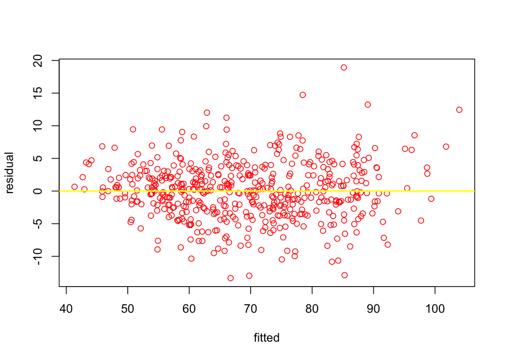

```r
skel_bic_RSS =sum(summary(skel_bic)$residuals^2)
plot(fitted(skel_bic), resid(skel_bic), col = "red", xlab = "fitted", ylab = "residual")
abline(h = 0, col = "yellow", lwd = 2)
```

```r
shapiro.test(resid(skel_bic))
```

```
##
##  Shapiro-Wilk normality test
##
## data:  resid(skel_bic)
## W = 0.99, p-value = 0.02
```

```r
skel_bic= lm(Weight~Age+Height+s1+s2+s3+s4+s5+s7+s8, data=body)
summary(skel_bic)$adj.r.squared
```

```
## [1] 0.8893
```

```r
skel_RSS =sum(summary(skel_bic)$residuals^2)
c_rmse(skel_bic)
```

```
## [1] 4.496
```

**(b)** Find a good model for `Weight` using only the Girth variables as well as `Age`, `Height`, and `Gender`. You are not allowed to remove any data or transform the response.

```r
model_g = lm(Weight~g1+g2+g3+g4+g5+g6+g7+g8+g9+g10+g11+g12+Age+Height+Gender, data=body)
summary(model_g)$adj.r.squared
```

```
## [1] 0.9734
```

```r
gmod_rss =sum(summary(model_g)$residuals^2)
c_rmse(model_g)
```

```
## [1] 2.224
```

```r
n=length(resid(model_g))
gmod_bic= step(model_g, direction= "backward", k=log(n), trace=0)
gmod_bic
```

```
##
## Call:
## lm(formula = Weight ~ g1 + g2 + g3 + g5 + g6 + g8 + g9 + g10 +
##     Age + Height, data = body)
##
## Coefficients:
## (Intercept)           g1           g2           g3           g5           g6
##   -119.0823       0.0706       0.2064       0.3602       0.2638       0.2848
##          g8           g9          g10          Age       Height
##      0.5340       0.2869       0.3956      -0.0370       0.3186
```

```r
summary(gmod_bic)$adj.r.squared
```

```
## [1] 0.9734
```

```r
g_bic_rss =sum(summary(gmod_bic)$residuals^2)
c_rmse(skel_bic)
```

```
## [1] 4.496
```

**(c)** Based on **(a)** and **(b)**, which set of body measurements are more useful for predicting `Weight`.

```r
#The second's body measurements are more useful for predicting the weights.
```

**(d)** Using all available variables, devise and justify a good model for predicting `Weight`. It should use less than 50 parameters and obtain a LOOCV RMSE less than 1.9. You are not allowed to remove any data or transform the response.

```r
c_rmse = function(model) {
  sqrt(mean((resid(model) / (1 - hatvalues(model))) ^ 2))
}

mall=lm(Weight~. , data=body)
(step(mall, direction="backward", trace=0))
```

```
##
## Call:
## lm(formula = Weight ~ s2 + s4 + s5 + s6 + s8 + g1 + g2 + g3 +
##     g5 + g6 + g8 + g9 + g10 + Age + Height + Gender, data = body)
##
## Coefficients:
## (Intercept)           s2           s4           s5           s6           s8
##   -121.1138       0.0945       0.2800       0.1242       0.2640       0.4500
##          g1           g2           g3           g5           g6           g8
##      0.0794       0.1470       0.3746       0.2062       0.2613       0.5296
##          g9          g10          Age       Height       Gender
##      0.1862       0.3401      -0.0561       0.2949      -1.4233
```

```r
(step(mall, direction = "backward", k=log(length(resid(mall))), trace=0))
```

```
##
## Call:
## lm(formula = Weight ~ s4 + s8 + g1 + g2 + g3 + g5 + g6 + g8 +
##     g10 + Age + Height + Gender, data = body)
##
## Coefficients:
## (Intercept)           s4           s8           g1           g2           g3
##   -122.2611       0.2658       0.6405       0.0865       0.1619       0.3858
##          g5           g6           g8          g10          Age       Height
##      0.2333       0.2578       0.5943       0.4057      -0.0533       0.3225
##      Gender
##     -1.5795
```

```r
anova((step(mall, direction="backward", trace=0)), (step(mall, direction = "backward", k=log(length(resid(mall))), trace=0)))
```

```
## Analysis of Variance Table
##
## Model 1: Weight ~ s2 + s4 + s5 + s6 + s8 + g1 + g2 + g3 + g5 + g6 + g8 +
##     g9 + g10 + Age + Height + Gender
## Model 2: Weight ~ s4 + s8 + g1 + g2 + g3 + g5 + g6 + g8 + g10 + Age +
##     Height + Gender
##   Res.Df  RSS Df Sum of Sq    F Pr(>F)
## 1    490 2144
## 2    494 2208 -4     -63.5 3.63 0.0063 **
## ---
## Signif. codes:  0 '***' 0.001 '**' 0.01 '*' 0.05 '.' 0.1 ' ' 1
```

```r
aic_mall= lm(Weight ~ Age+s2*s4+s5+s6*s8+g1*g2 +g3*g5 + g6*g8+g9*g10+Height*Gender, data=body)
summary(aic_mall)
```

```
##
## Call:
## lm(formula = Weight ~ Age + s2 * s4 + s5 + s6 * s8 + g1 * g2 +
##     g3 * g5 + g6 * g8 + g9 * g10 + Height * Gender, data = body)
##
## Residuals:
##    Min     1Q Median     3Q    Max
## -6.696 -1.170 -0.024  1.174  7.118
##
## Coefficients:
##                Estimate Std. Error t value Pr(>|t|)
## (Intercept)   -23.58200   15.05309   -1.57  0.11787
## Age            -0.04763    0.01116   -4.27 0.000024 ***
## s2             -0.33683    0.37089   -0.91  0.36425
## s4             -0.43534    0.54405   -0.80  0.42400
## s5              0.07066    0.07213    0.98  0.32777
## s6              0.56320    1.09366    0.51  0.60681
## s8              0.75553    0.79943    0.95  0.34509
## g1             -0.35581    0.11664   -3.05  0.00241 **
## g2             -0.35136    0.14032   -2.50  0.01261 *
## g3              0.01605    0.18153    0.09  0.92956
## g5             -0.05959    0.14915   -0.40  0.68967
## g6              0.36845    0.30732    1.20  0.23116
## g8              0.73639    0.65838    1.12  0.26391
## g9             -0.27770    0.46605   -0.60  0.55154
## g10            -0.11850    0.45382   -0.26  0.79412
## Height          0.26819    0.02223   12.06  < 2e-16 ***
## Gender        -12.78975    4.82754   -2.65  0.00833 **
## s2:s4           0.02283    0.01933    1.18  0.23804
## s6:s8          -0.01584    0.05748   -0.28  0.78305
## g1:g2           0.00459    0.00120    3.82  0.00015 ***
## g3:g5           0.00345    0.00180    1.92  0.05583 .
## g6:g8          -0.00301    0.01131   -0.27  0.79005
## g9:g10          0.01226    0.01246    0.98  0.32543
## Height:Gender   0.06953    0.02826    2.46  0.01425 *
## ---
## Signif. codes:  0 '***' 0.001 '**' 0.01 '*' 0.05 '.' 0.1 ' ' 1
##
## Residual standard error: 1.93 on 483 degrees of freedom
## Multiple R-squared:  0.98,   Adjusted R-squared:  0.979
## F-statistic: 1.03e+03 on 23 and 483 DF,  p-value: <2e-16
```

```r
c_rmse(aic_mall)
```

```
## [1] 1.994
```